# Ash_A07

Jamie Ash

due: 2021-03-06

```r
HDIofMCMC <- function( sampleVec , credMass=0.95 ) {
  # Computes highest density interval from a sample of representative values.
  # Arguments:
  #   sampleVec
  #     is a vector of representative values from a probability distribution.
  #   credMass
  #     is a scalar between 0 and 1, indicating the mass within the credible
  #     interval that is to be estimated.
  # Value:
  #   HDIlim is a vector containing the limits of the HDI
  # Credit: John K. Kruschke, "Doing Bayesian Data Analysis, 2nd edition"
  sortedPts <- sort( sampleVec )
  ciIdxInc <- # How many sample elements are in the CI?
    ceiling( credMass * length( sortedPts ) )
  nCIs <-     # number of possible CIs
    length( sortedPts ) - ciIdxInc
  ciWidth <- rep( 0 , nCIs ) # create storage
  for ( i in 1:nCIs ) {
    ciWidth[ i ] <- # last value in CI - first value in CI
      sortedPts[ i + ciIdxInc ] - sortedPts[ i ]
  } # end for
  HDImin <- sortedPts[ which.min( ciWidth ) ]
  HDImax <- sortedPts[ which.min( ciWidth ) + ciIdxInc ]
  HDIlim <- c( HDImin , HDImax )
  return( HDIlim )
}
```

# Goals

The goals of this assignment are: (1) Math review: domains and ranges; (2) Odds and probability—the equivalence of the reciprocal density for odds with the Haldane density for probability; (3) Using JAGS to estimate the change points in a regime change problem; (4) Convenient MCMC diagnostics using Kruschke’s `diagMCMC()` function.

# Tiny tips

- Can’t remember the TeX word, or the math name, for a particular symbol? Go to [detexify](http://detexify.kirelabs.org/classify.html), draw the symbol and the LaTeX will appear.
- The ubiquitous chi-square distribution with $\nu$ degrees of freedom, indicated by the notations $\theta \sim \chi_\nu^2$ or $p(\theta)=\chi_\nu^2(\theta)$, is just a one-parameter gamma distribution with $\alpha=\nu/2$, $\beta=1/2$.
- In data analysis and statistics you often see the phrase “conditional independence”. To see what that means consider a PDF $p(x,y|z)$. If $p(x,y|z)=p(x|z)\,p(y|z)$ then $x$ and $y$ are said to be conditionally independent given $z$. Conditional independence differs from independence, and neither one implies the other.
- One of the hardest things to get used to in coding is that the code needed to test the code you really want is often much longer than the code being tested. Professional coders take this in stride, but we amateurs must work to conquer our chagrin.

# Ex 1. Vocabulary

(15 pts) The *domain* of a function $f(x)$ is the set of x’s on which it is defined. Thus $f(x)=x^2;\ x\gt 0$ is a different function than $f(x)=x^2;\ -\infty \lt x \lt \infty$ because the domain of the former is the positive real numbers, whereas the domain of the latter is the entire real line. The former has a well-defined inverse $f^{-1}(x)=\sqrt{x}$, whereas the latter does not. The *range* of a function is the set of values $f(x)$ where $x$ is an element of the domain.

If $X$ is a random variable its cumulative distribution function (CDF), written $F_X(x)$ is the probability that $X$ will take a value less than or equal to $x$. Thus $F_X(x)=\Pr(X \le x)$. The Normal CDF is used so frequently that it has its own symbol, $\Phi$. Thus $\Phi(x|\mu,\sigma)=\Pr(X \le x|\mu,\sigma)$. In R, as you know, the Normal PDF is `dnorm(x, mean, sd)` and the Normal CDF is `pnorm(q, mean, sd)`.

Complete the following statements:

1. The domain of the Normal PDF $N(x|\mu,\sigma)$ is $- \infty$ to $\infty$.
2. It’s range is $0$ to $\infty$.
3. The domain of the Normal CDF (often denoted by $\Phi(x|\mu,\sigma)$), is $-\infty$ to $\infty$.
4. Its range is 0 to 1.
5. The domain of the Normal inverse CDF (quantile function), often denoted by $\Phi^{-1}(p|\mu,\sigma)$, is 0 to 1.
6. Its range is 0 to $\infty$.
7. The domain of the beta PDF is 0 to 1.
8. Its range is 0 to $\infty$.
9. The domain of the beta CDF is 0 to $\infty$.
10. Its range is 0 to 1.
11. The domain of the beta inverse CDF (quantile function) is 0 to 1.
12. Its range is 0 to 1.
13. The domain of a Poisson PMF $\Pr(y|\lambda)=e^{-\lambda}\lambda^y/y!$ is $0$ to $\infty$
14. Its range is the set of numbers 0 to 1.

```r
pbeta(seq(-5, 10, by=0.1), shape1=0.5, shape2=0.5)
pnorm(seq(-5, 10, by=0.1), mean=3, sd=1)
dpois(seq(-5, 10, by=1), 2)
dgamma(-1:10, 5, 5)
```

# Ex 2. Odds

## Notation

So that we won’t have to use the proportional sign $\propto$, let’s agree to denote a generic density (i.e., an *improper* PDF), by $q$ instead of $p$. For example, if we are talking about the reciprocal density $1/r$, instead of writing $p(r)\propto 1/r$ we will just write $q(r)=1/r$.

## Review

In Ex 2 of the previous assignment (A05) you used the posterior mean to show that the uninformative prior for the rate $r$ of a Poisson process likelihood is the reciprocal prior $1/r$. In Ex 3 of that assignment you used conservation of probability to show that $q_r(r)= 1/r$ (in the example there, $r$ was the population density of female cougars in units of cougars per km<sup>2</sup>) is equivalent to a reciprocal prior for $q_s(s)=1/s$ ($s=1/r$ is territory size in km<sup>2</sup> per female cougar). This equivalence is sensible because a density that is uninformative for animals per km<sup>2</sup> should be equally uninformative for km<sup>2</sup> per animal; neither quantity is more fundamental than the other.

In Ex 1 of assignment A04 (the beta-binomial example) you used the posterior mean to show that the uniformative prior for a binomial likelihood with probability parameter $\phi$ is the Haldane density $q(\phi)=\phi^{-1}(1-\phi)^{-1}$.

In this exercise you will explore the connection between the reciprocal density and the Haldane density. To do that we need the concept of *odds.* If $\phi$ is the probability of an event, then the *odds* (for) the event is defined as $\omega=\phi/(1-\phi)$ and the *odds-against* is defined as $\omega_a=(1-\phi)/\phi$.

Notice that both the odds (for) and the odds-against both range from 0 to $\infty$. Neither type of odds is more fundamental or meaningful than the other, so the uninformative density for one of them should be the same as the uninformative density for the other. Moreover, they are both ratio scale quantities, so the uninformative density for both odds, and odds-against, must be the reciprocal density $q(\omega)=1/\omega;\ q(\omega_a)=1/\omega_a$. That relation is consistent with conservation of probability because $\omega_a=1/\omega$.

With all that in mind: **(a)** first show in a LaTeX derivation that $\phi=\omega/(1+\omega)$; and then **(b)** demonstrate in LaTeX that the reciprocal density for the odds is equivalent under conservation of probability to the Haldane density for the probability. In other words, show that

$$q_\omega(\omega)=1/\omega \underset{\text{ CoP}}{\iff} q_\phi(\phi)=\phi^{-1}(1-\phi)^{-1}$$
Hint: Start with $q_\phi(\phi)$ on the left hand side and $q_\omega(\omega)|d\omega/d\phi|$ on the right hand side.

**Answer Ex2 (a):**
$$\begin{align}
&\omega=\phi/(1-\phi)
&\textrm{odds for} \\
&\omega (1-\phi)=\phi
&\textrm{multiply by (1-phi)} \\
&\omega - \omega \phi=\phi
&\textrm{multiply across} \\
&\phi(\omega/\phi - \omega)=\phi
&\textrm{pull out} \\
&\omega/\phi - \omega=1
&\textrm{divide by phi} \\
&\omega/\phi=1 + \omega
&\textrm{move w over} \\
&1/\phi=(1 + \omega)/\omega
&\textrm{multiply by 1/w} \\
&\phi=\omega/(1 + \omega)
&\textrm{flip it} \\
\end{align}$$

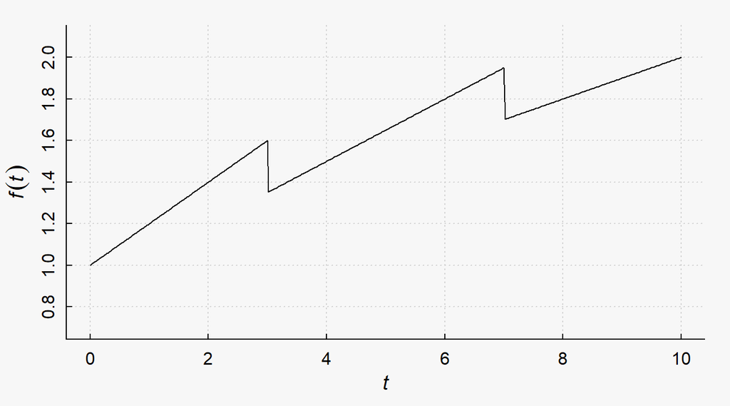

Figure 1: A function that is piecewise linear with change points at t=3 and t=7.

```r
cp <- c(3, 7)
t <- seq(0,10,len=501)
t1 <- pmin(t, cp[1])
t2 <- pmin(t, cp[2]) - cp[1]
t3 <- pmax(t, cp[2]) - cp[2]

a=c(1.00, -0.25, -0.25)
b=c(0.20,  0.15,  0.10)

## Impure functions for easy correspondence with the math
f1 <- function(t) a[1] + b[1]*t
f2 <- function(t) a[2] + b[2]*t
f3 <- function(t) a[3] + b[3]*t

H <- function(t) as.numeric(t > 0) # step function

f <- f1(t1) + f2(t2)*H(t-cp[1]) + f3(t3)*H(t-cp[2])

mypar()
plot(t,f,type="l", ylim=c(0.7, 1.05*max(f)),
     xlab="", ylab="", panel.first=grid())
xlab <- expression(italic(t))
ylab <- expression(italic(f(t)))
title(xlab=xlab, ylab=ylab, cex.lab=1.2)
```

The easiest way to handle a function like this is the [cumulative indicator formulation](https://osf.io/fzqxv): Here is the equation, with the indicators on the right. Notice the convenient “change of origin” for each function.

$$f(t) = \left\{ \begin{array}{lcr}
f_1(t) &t \le \xi_1 \\
f_1(\xi_1) + f_2(t - \xi_1) &\xi_1 \lt t \le \xi_2 \\
f_1(\xi_1) + f_2(\xi_1) + f_3(t-\xi_2) &\xi_2 \lt t
\end{array} \right.
\tag{1}$$

As a prelude to coding this, we introduce the quantities:

$$\begin{align}
t_1&=\min(t,\xi_1)\\
t_2&=\min(t,\xi_2) - \xi_1\\
t_3&=\max(t,\xi_2) - \xi_2.
\end{align}
\tag{2}$$

We can now write equation (1) as

$$f(t) = \left\{ \begin{array}{lcr}
f_1(t_1) &t \le \xi_1 \\
f_1(t_1) + f_2(t_2) &\xi_1 \lt t \le \xi_2 \\
f_1(t_1) + f_2(t_2) + f_3(t_3) &\xi_2 \lt t
\end{array}
\right. \tag{3}$$
However, that is still a rather awkward expression, requiring if-statements to code. To fix that situation, we make use of the step function defined by $H(t)=I(t>0)$ where $I()$ is the familiar indicator function—see A01. We can now write $f(t)$ like this[^2]

$$f(t) = f_1(t_1) + f_2(t_2)H(t-t_1) + f_3(t_3)H(t-t_2)
\tag{4}$$

Now here is the exercise: Show that you understand the above formulation by rewriting equations (1) - (4), adding a third change point and fourth function.

**Answer Ex3:** Below, I’ve rewritten the above formulation, adding a third change point and fourth function.
$$f(t) = \left\{ \begin{array}{lcr}
f_1(t) &t \le \xi_1 \\
f_1(\xi_1) + f_2(t - \xi_1) &\xi_1 \lt t \le \xi_2 \\
f_1(\xi_1) + f_2(\xi_2) + f_3(t-\xi_2) &\xi_2 \lt t \le \xi_3 \\
f_1(\xi_1) + f_2(\xi_2) + f_3(\xi_3) + f_4(t-\xi_3) &\xi_3 \lt t
\end{array} \right.$$

$$\begin{align}
t_1&=\min(t,\xi_1)\\
t_2&=\min(t,\xi_2) - \xi_1\\
t_3&=\min(t,\xi_3) - \xi_2\\
t_4&=\max(t,\xi_3) - \xi_3
\end{align}$$

$$f(t) = \left\{ \begin{array}{lcr}
f_1(t_1) &t \le \xi_1 \\
f_1(t_1) + f_2(t_2) &\xi_1 \lt t \le \xi_2 \\
f_1(t_1) + f_2(t_2) + f_3(t_3) &\xi_2 \lt t \le \xi_3 \\
f_1(t_1) + f_2(t_2) + f_3(t_3) + f_4(t_4) &\xi_3 \lt t
\end{array}
\right.$$

$$f(t) = f_1(t_1) + f_2(t_2)H(t-\xi_1) + f_3(t_3)H(t-\xi_2) + f_4(t_4)H(t-\xi_3)$$